# Bootstrap & MCMC Tutorial

## Markov Chain Monte Carlo (MCMC) GLMM

Now let’s try a different randomization method that also incorporates more complexity from our data. We initially built a simple model with only a response and a single predictor. But in this dataset, we also know there are individuals that may differ in their behavior and we might expect that behavior differs by day, depending on flockmates and other factors. We can incorporate that complexity into the model and into the randomization process itself with MCMC.

Let’s run through the logic for MCMC before we continue. These models are complex, and the function we will use “black-boxes” the methods.

```r
library(MCMCglmm)
??MCMCglmm
```

The way that MCMC randomizes data is actually by simulating a new data “chain” using a probability of moving from one point to another. As the data is simulated, we might find that data points simulated one after the other are dependent on the previous point. This is important to know because one of the assumptions of a linear model is that data points are independent of each other. To account for this, we can discard every nth data point to maintain independence. We can adjust this with the “thin” argument.

It’s also possible that when the chain starts, its first set of simulated data points are less random than as the simulation continues. We may then want to discard osbervations from the beginning of the chain. We can adjust this using the “burnin” argument.

One great thing about the MCMCMglmm package is that it has nifty built-in functions to run diagnostic tests to find the best parameters for the model. We can find the optimum burn-in period, sample size (total), and dependence factor (nth step without losing important info).

```r
raftery.diag(morn_visits$sumvisits, q = 0.05)
```

```
##
## Quantile (q) = 0.05
## Accuracy (r) = +/- 0.005
## Probability (s) = 0.95
##
## You need a sample size of at least 7299 with these values of q, r and s
```

```r
glmm.1 <- MCMCglmm(fixed = sumvisits~nightlows,
                   random = ~RFID+Date,
                   family = "poisson",
                   data = morn_visits,
                   nitt = 7400,
                   burnin = 100,
                   thin = 1)
```

```
##
##                        MCMC iteration = 0
##
##  Acceptance ratio for liability set 1 = 0.000315
##
##                        MCMC iteration = 1000
##
##  Acceptance ratio for liability set 1 = 0.397322
##
##                        MCMC iteration = 2000
##
##  Acceptance ratio for liability set 1 = 0.400381
##
##                        MCMC iteration = 3000
##
##  Acceptance ratio for liability set 1 = 0.401224
##
##                        MCMC iteration = 4000
##
##  Acceptance ratio for liability set 1 = 0.400049
##
##                        MCMC iteration = 5000
##
##  Acceptance ratio for liability set 1 = 0.399919
##
##                        MCMC iteration = 6000
##
##  Acceptance ratio for liability set 1 = 0.399849
##
##                        MCMC iteration = 7000
##
##  Acceptance ratio for liability set 1 = 0.400805
```

Let’s look at the residuals. Again, there should be no clear trends–the messier, the better.

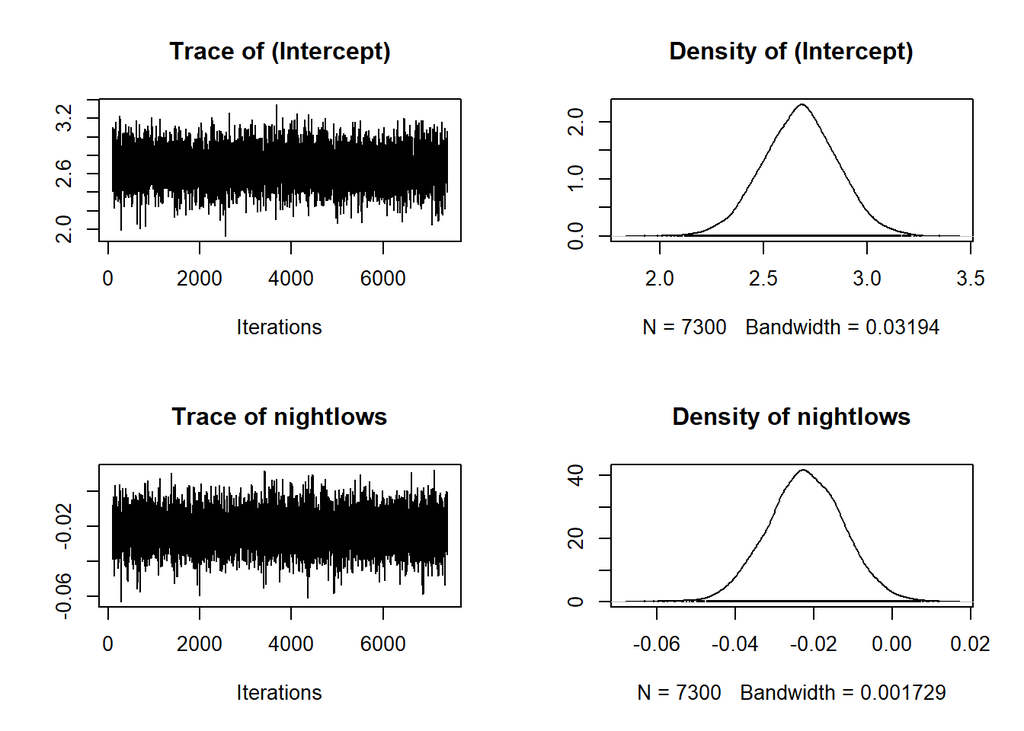

```r
plot(glmm.1$Sol)
```

These look pretty good.

```r
autocorr(glmm.1$Sol)
```

```
## , , (Intercept)
##
##         (Intercept)     nightlows
## Lag 0   1.000000000  0.6843990990
## Lag 1   0.008967196  0.0114472219
## Lag 5   0.006243232 -0.0002864469
## Lag 10 -0.019514316 -0.0056234806
## Lag 50 -0.016862066 -0.0234951404
##
## , , nightlows
##
##          (Intercept)    nightlows
## Lag 0   0.6843990990  1.000000000
## Lag 1   0.0110591045  0.015821868
## Lag 5   0.0156491389  0.011861528
## Lag 10 -0.0083865158  0.008530944
## Lag 50  0.0005504137 -0.004213824
```

There is very low autocorrelation between points, so that is good.

We can also check model performance by running multiple chains and making sure they are all well mixed. We will use parallel processing to make this part go faster.

```r
library(doParallel)
library(foreach)
# Initialize parallel backend
registerDoParallel(cores = 4)
# Use foreach to parallelize the loop
timestamp()
```

```
## ##------ Mon Jun 24 11:43:51 2024 ------##
```

```r
set.seed(1)
glmm.mult <- foreach(i = 1:4, .packages = 'MCMCglmm') %dopar% {
    MCMCglmm(fixed = sumvisits~nightlows,
             random = ~RFID+Date,
             family = "poisson",
             data = morn_visits,
             nitt = 7300,
             burnin = 8)
}
timestamp()
```

```
## ##------ Mon Jun 24 11:43:58 2024 ------##
```

```r
# Stop parallel backend-- DON'T FORGET TO DO THIS!
stopImplicitCluster()

glmm.mult.1 <- lapply(glmm.mult, function(m) m$Sol)
glmm.mult.1 <- do.call(mcmc.list, glmm.mult.1)
```

Potential scale reduction factors (PSRF) should be close to one, ideally < 1.2.

```r
gelman.diag(glmm.mult.1)
```

```
## Potential scale reduction factors:
##
##             Point est. Upper C.I.
## (Intercept)          1          1
## nightlows            1          1
##
## Multivariate psrf
##
## 1.01
```

[output not shown]

[output not shown]

[output not shown]

PSRF value is good, now let’s look at the chains to make sure they are well mixed. For this plot, no line color should stand out in its own pattern, it should still be super messy, this means the chains all converged on similar answers and that the model fit is good.

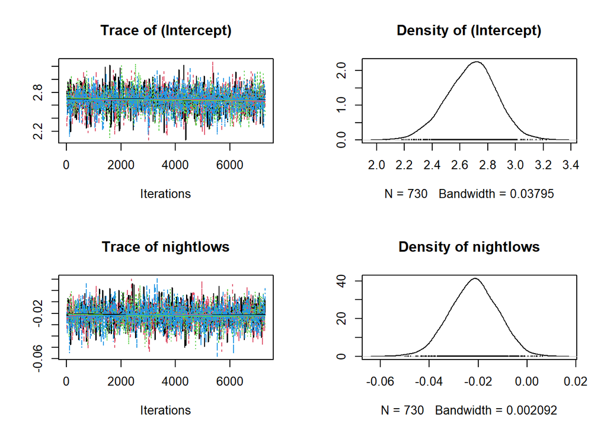

```r
plot(glmm.mult.1)
```

[figure not shown]

These look well mixed, so we can be confident that we have a good model fit. MCMC also gives us confidence intervals, so we can also assess the accuracy of our model parameters. We can also use confidence intervals for simple hypothesis testing; i.e., if the parameters overlap with zero, we absolutely cannot reject the null hypothesis, but if not and p-values fall below 0.05, we can reject with relative confidence. FYI the following plot code was adapted from a MCMCglmm tutorial (link at the bottom of the page).

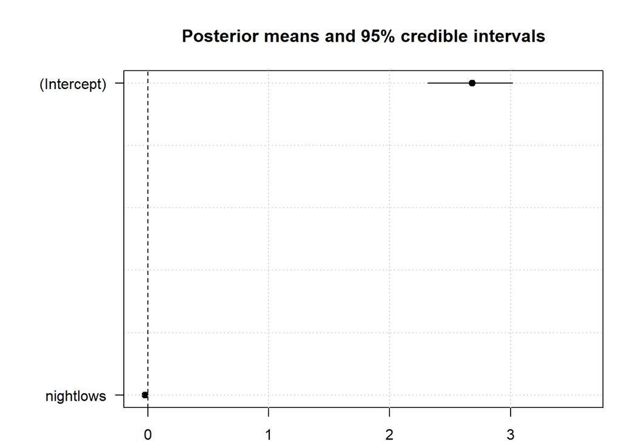

```r
  x <- summary(glmm.mult.1)
  n <- dim(x$statistics)[1]
  par(mar=c(2, 7, 4, 1))
  plot(x$statistics[,1], n:1,
       yaxt="n", ylab="",
       xlim=range(x$quantiles)*1.2,
       pch=19,
       main="Posterior means and 95% credible intervals")
  grid()
  axis(2, at=n:1, rownames(x$statistics), las=2)
  arrows(x$quantiles[,1], n:1, x$quantiles[,5], n:1, code=0)
  abline(v=0, lty=2)
```

[figure not shown]

The basic procedure I described was adopted from ECOLOGICAL MODELS AND DATA IN R: 7.3 - MARKOV CHAIN MONTE CARLO (PAGE 233). There are many more details there. I also used a custom function from an intro to MCMCglmm resource, which follows this same procedure and adds some more details. You should peruse to find more examples and more detailed explanation: https://github.com/tmalsburg/MCMCglmm-intro. And one more resource: http://cran.nexr.com/web/packages/MCMCglmm/vignettes/CourseNotes.pdf

Another great resource for understanding these types of Bayesian models is Richard McElreath’s Statistical Rethinking course: https://github.com/rmcelreath/stat_rethinking_2023.